# Comcast_complaint

```python
import pandas as pd
import numpy as np
import matplotlib as mp
import scipy
import scipy.stats
import tensorflow as tf
#import tensorflow_hub as hub
import json
import pickle
import urllib

from sklearn.preprocessing import LabelBinarizer

print(tf.__version__)
```

```
2.1.0
```

Import data into Python environment.

```python
b=pd.read_csv("Comcast_telecom_complaints_data.csv") #import dataset
# 1 Import
a=b
```

```python
#import datetime as dt #import datetime
import matplotlib.pyplot as plt
a.dtypes
```

```
Ticket #                       object
Customer Complaint             object
Date                           object
Date_month_year                object
Time                           object
Received Via                   object
City                           object
State                          object
Zip code                        int64
Status                         object
Filing on Behalf of Someone    object
dtype: object
```

Convert into datetime datatype

```python
a['Datetime']=a['Date_month_year']+" "+a['Time']
a['Datetime']=pd.to_datetime(a['Datetime'])
#apply(lambda row: np.nan if type(row)==type(0.0)\
#else(dt.datetime.strptime(row,"%d-%m-%y")))
a.Datetime
```

```
0      2015-04-22 15:53:50
1      2015-08-04 10:22:56
2      2015-04-18 09:55:47
3      2015-07-05 11:59:35
4      2015-05-26 13:25:26
               ...
2219   2015-02-04 09:13:18
2220   2015-02-06 13:24:39
2221   2015-09-06 17:28:41
2222   2015-06-23 23:13:30
2223   2015-06-24 22:28:33
Name: Datetime, Length: 2224, dtype: datetime64[ns]
```

```python
a.dtypes
```

```
Ticket #                               object
Customer Complaint                     object
Date                                   object
Date_month_year                        object
Time                                   object
Received Via                           object
City                                   object
State                                  object
Zip code                                int64
Status                                 object
Filing on Behalf of Someone            object
Datetime                       datetime64[ns]
dtype: object
```

```python
a['Date_month_year_dt']=pd.to_datetime(a['Date_month_year'])
```

```python
a.dtypes
```

```
Ticket #                               object
Customer Complaint                     object
Date                                   object
Date_month_year                        object
Time                                   object
Received Via                           object
City                                   object
State                                  object
Zip code                                int64
Status                                 object
Filing on Behalf of Someone            object
Datetime                       datetime64[ns]
Date_month_year_dt             datetime64[ns]
dtype: object
```

Set index as date time check how it works

```python
a=a.set_index(a['Datetime'])
```

```python
a.head()
```

| Datetime | Ticket # | Customer Complaint | Date | Date_month_year | Time | Received Via | City | State | Zip code | Status | Filing on Behalf of Someone | Datetime | Date_month_year_dt |
| --- | --- | --- | --- | --- | --- | --- | --- | --- | --- | --- | --- | --- | --- |
| 2015-04-22 15:53:50 | 250635 | Comcast Cable Internet Speeds | 22-04-15 | 22-Apr-15 | 3:53:50 PM | Customer Care Call | Abingdon | Maryland | 21009 | Closed | No | 2015-04-22 15:53:50 | 2015-04-22 |
| 2015-08-04 10:22:56 | 223441 | Payment disappear - service got disconnected | 04-08-15 | 04-Aug-15 | 10:22:56 AM | Internet | Acworth | Georgia | 30102 | Closed | No | 2015-08-04 10:22:56 | 2015-08-04 |
| 2015-04-18 09:55:47 | 242732 | Speed and Service | 18-04-15 | 18-Apr-15 | 9:55:47 AM | Internet | Acworth | Georgia | 30101 | Closed | Yes | 2015-04-18 09:55:47 | 2015-04-18 |
| 2015-07-05 11:59:35 | 277946 | Comcast Imposed a New Usage Cap of 300GB that ... | 05-07-15 | 05-Jul-15 | 11:59:35 AM | Internet | Acworth | Georgia | 30101 | Open | Yes | 2015-07-05 11:59:35 | 2015-07-05 |
| 2015-05-26 13:25:26 | 307175 | Comcast not working and no service to boot | 26-05-15 | 26-May-15 | 1:25:26 PM | Internet | Acworth | Georgia | 30101 | Solved | No | 2015-05-26 13:25:26 | 2015-05-26 |

```python
a['2015']
```

| Datetime | Ticket # | Customer Complaint | Date | Date_month_year | Time | Received Via | City | State | Zip code | Status | Filing on Behalf of Someone | Datetime | Date_month_year_dt |
| --- | --- | --- | --- | --- | --- | --- | --- | --- | --- | --- | --- | --- | --- |
| 2015-04-22 15:53:50 | 250635 | Comcast Cable Internet Speeds | 22-04-15 | 22-Apr-15 | 3:53:50 PM | Customer Care Call | Abingdon | Maryland | 21009 | Closed | No | 2015-04-22 15:53:50 | 2015-04-22 |
| 2015-08-04 10:22:56 | 223441 | Payment disappear - service got disconnected | 04-08-15 | 04-Aug-15 | 10:22:56 AM | Internet | Acworth | Georgia | 30102 | Closed | No | 2015-08-04 10:22:56 | 2015-08-04 |
| 2015-04-18 09:55:47 | 242732 | Speed and Service | 18-04-15 | 18-Apr-15 | 9:55:47 AM | Internet | Acworth | Georgia | 30101 | Closed | Yes | 2015-04-18 09:55:47 | 2015-04-18 |
| 2015-07-05 11:59:35 | 277946 | Comcast Imposed a New Usage Cap of 300GB that ... | 05-07-15 | 05-Jul-15 | 11:59:35 AM | Internet | Acworth | Georgia | 30101 | Open | Yes | 2015-07-05 11:59:35 | 2015-07-05 |
| 2015-05-26 13:25:26 | 307175 | Comcast not working and no service to boot | 26-05-15 | 26-May-15 | 1:25:26 PM | Internet | Acworth | Georgia | 30101 | Solved | No | 2015-05-26 13:25:26 | 2015-05-26 |
| ... | ... | ... | ... | ... | ... | ... | ... | ... | ... | ... | ... | ... | ... |
| 2015-02-04 09:13:18 | 213550 | Service Availability | 04-02-15 | 04-Feb-15 | 9:13:18 AM | Customer Care Call | Youngstown | Florida | 32466 | Closed | No | 2015-02-04 09:13:18 | 2015-02-04 |
| 2015-02-06 13:24:39 | 318775 | Comcast Monthly Billing for Returned Modem | 06-02-15 | 06-Feb-15 | 1:24:39 PM | Customer Care Call | Ypsilanti | Michigan | 48197 | Solved | No | 2015-02-06 13:24:39 | 2015-02-06 |
| 2015-09-06 17:28:41 | 331188 | complaint about comcast | 06-09-15 | 06-Sep-15 | 5:28:41 PM | Internet | Ypsilanti | Michigan | 48197 | Solved | No | 2015-09-06 17:28:41 | 2015-09-06 |
| 2015-06-23 23:13:30 | 360489 | Extremely unsatisfied Comcast customer | 23-06-15 | 23-Jun-15 | 11:13:30 PM | Customer Care Call | Ypsilanti | Michigan | 48197 | Solved | No | 2015-06-23 23:13:30 | 2015-06-23 |
| 2015-06-24 22:28:33 | 363614 | Comcast, Ypsilanti MI Internet Speed | 24-06-15 | 24-Jun-15 | 10:28:33 PM | Customer Care Call | Ypsilanti | Michigan | 48198 | Open | Yes | 2015-06-24 22:28:33 | 2015-06-24 |

2224 rows × 13 columns

```python
a['2015-12']
```

| Datetime | Ticket # | Customer Complaint | Date | Date_month_year | Time | Received Via | City | State | Zip code | Status | Filing on Behalf of Someone | Datetime | Date_month_year_dt |
| --- | --- | --- | --- | --- | --- | --- | --- | --- | --- | --- | --- | --- | --- |
| 2015-12-06 21:59:40 | 338519 | ISP Charging for arbitrary data limits with ov... | 06-12-15 | 06-Dec-15 | 9:59:40 PM | Internet | Acworth | Georgia | 30101 | Solved | No | 2015-12-06 21:59:40 | 2015-12-06 |
| 2015-12-06 15:59:57 | 337489 | Comcast not refunding my credit | 06-12-15 | 06-Dec-15 | 3:59:57 PM | Internet | Alpharetta | Georgia | 30005 | Solved | No | 2015-12-06 15:59:57 | 2015-12-06 |
| 2015-12-05 21:06:01 | 286768 | not getting what I am paying for with internet | 05-12-15 | 05-Dec-15 | 9:06:01 PM | Customer Care Call | Andover | Minnesota | 55304 | Solved | No | 2015-12-05 21:06:01 | 2015-12-05 |
| 2015-12-04 15:22:03 | 231273 | Comcast's Monopolistic Practices and Data Capping | 04-12-15 | 04-Dec-15 | 3:22:03 PM | Internet | Atlanta | Georgia | 30315 | Closed | No | 2015-12-04 15:22:03 | 2015-12-04 |
| 2015-12-04 15:45:26 | 231292 | Comcast data cap "trials" | 04-12-15 | 04-Dec-15 | 3:45:26 PM | Internet | Atlanta | Georgia | 30316 | Closed | No | 2015-12-04 15:45:26 | 2015-12-04 |
| ... | ... | ... | ... | ... | ... | ... | ... | ... | ... | ... | ... | ... | ... |
| 2015-12-06 13:18:20 | 336982 | Comcast monopoly | 06-12-15 | 06-Dec-15 | 1:18:20 PM | Internet | Tukwila | Washington | 98188 | Solved | No | 2015-12-06 13:18:20 | 2015-12-06 |
| 2015-12-04 19:39:11 | 231419 | over sold/ over billed for short term services | 04-12-15 | 04-Dec-15 | 7:39:11 PM | Customer Care Call | Wenonah | New Jersey | 8090 | Closed | No | 2015-12-04 19:39:11 | 2015-12-04 |
| 2015-12-06 11:49:17 | 336674 | Data caps for cable ISP;s | 06-12-15 | 06-Dec-15 | 11:49:17 AM | Customer Care Call | Westminster | Colorado | 80021 | Solved | No | 2015-12-06 11:49:17 | 2015-12-06 |
| 2015-12-06 14:45:21 | 337251 | Unfair Pricing | 06-12-15 | 06-Dec-15 | 2:45:21 PM | Customer Care Call | Woburn | Massachusetts | 1801 | Solved | No | 2015-12-06 14:45:21 | 2015-12-06 |
| 2015-12-06 18:35:59 | 338192 | Speed throttling, speeds not at promised output | 06-12-15 | 06-Dec-15 | 6:35:59 PM | Customer Care Call | Yorkville | Illinois | 60560 | Open | Yes | 2015-12-06 18:35:59 | 2015-12-06 |

65 rows × 13 columns

```python
a.sort_index(inplace=True)
```

```python
a.tail()
```

| Datetime | Ticket # | Customer Complaint | Date | Date_month_year | Time | Received Via | City | State | Zip code | Status | Filing on Behalf of Someone | Datetime | Date_month_year_dt |
| --- | --- | --- | --- | --- | --- | --- | --- | --- | --- | --- | --- | --- | --- |
| 2015-12-06 21:18:18 | 338467 | Cable internet unavailable | 06-12-15 | 06-Dec-15 | 9:18:18 PM | Internet | San Mateo | California | 94402 | Closed | No | 2015-12-06 21:18:18 | 2015-12-06 |
| 2015-12-06 21:46:12 | 338507 | Comcast Internet, cable, and phone outtages | 06-12-15 | 06-Dec-15 | 9:46:12 PM | Customer Care Call | Clarkston | Michigan | 48346 | Solved | No | 2015-12-06 21:46:12 | 2015-12-06 |
| 2015-12-06 21:51:40 | 338510 | Comcast | 06-12-15 | 06-Dec-15 | 9:51:40 PM | Internet | Muskegon | Michigan | 49445 | Solved | No | 2015-12-06 21:51:40 | 2015-12-06 |
| 2015-12-06 21:59:40 | 338519 | ISP Charging for arbitrary data limits with ov... | 06-12-15 | 06-Dec-15 | 9:59:40 PM | Internet | Acworth | Georgia | 30101 | Solved | No | 2015-12-06 21:59:40 | 2015-12-06 |
| 2015-12-06 23:52:11 | 338606 | Internet connection outage | 06-12-15 | 06-Dec-15 | 11:52:11 PM | Customer Care Call | Clarkston | Michigan | 48346 | Solved | No | 2015-12-06 23:52:11 | 2015-12-06 |

```python
a.head()
```

| Datetime | Ticket # | Customer Complaint | Date | Date_month_year | Time | Received Via | City | State | Zip code | Status | Filing on Behalf of Someone | Datetime | Date_month_year_dt |
| --- | --- | --- | --- | --- | --- | --- | --- | --- | --- | --- | --- | --- | --- |
| 2015-01-04 00:18:47 | 211255 | Comcast harassment | 04-01-15 | 04-Jan-15 | 12:18:47 AM | Customer Care Call | Schaumburg | Illinois | 60193 | Closed | No | 2015-01-04 00:18:47 | 2015-01-04 |
| 2015-01-04 10:43:20 | 211472 | comcast cable | 04-01-15 | 04-Jan-15 | 10:43:20 AM | Customer Care Call | Lockport | Illinois | 60441 | Closed | No | 2015-01-04 10:43:20 | 2015-01-04 |
| 2015-01-04 10:47:35 | 211478 | Comcast | 04-01-15 | 04-Jan-15 | 10:47:35 AM | Internet | North Huntingdon | Pennsylvania | 15642 | Closed | No | 2015-01-04 10:47:35 | 2015-01-04 |
| 2015-01-04 12:01:06 | 211677 | Comcast refusal of service | 04-01-15 | 04-Jan-15 | 12:01:06 PM | Customer Care Call | Wayne | Pennsylvania | 19087 | Closed | No | 2015-01-04 12:01:06 | 2015-01-04 |
| 2015-01-04 12:28:58 | 211775 | Horrible Service | 04-01-15 | 04-Jan-15 | 12:28:58 PM | Customer Care Call | Mckeesport | Pennsylvania | 15132 | Closed | No | 2015-01-04 12:28:58 | 2015-01-04 |

Set index as date month year dt and plot daily graph

```python
a=a.set_index(a['Date_month_year_dt'])
```

```python
#create new columns month day and day of year
a["month"]=a.apply(lambda row: row.Datetime.month,axis=1)#(row.ClosedDate.year))
```

Create a new month coluumn

```python
a.month
```

```
Date_month_year_dt
2015-01-04     1
2015-01-04     1
2015-01-04     1
2015-01-04     1
2015-01-04     1
              ..
2015-12-06    12
2015-12-06    12
2015-12-06    12
2015-12-06    12
2015-12-06    12
Name: month, Length: 2224, dtype: int64
```

```python
a['Date_month_year_dt'].value_counts()[:20]
```

```
2015-06-24    218
2015-06-23    190
2015-06-25     98
2015-06-26     55
2015-06-30     53
2015-06-29     51
2015-06-18     47
2015-12-06     43
2015-06-27     39
2015-06-15     34
2015-06-17     32
2015-06-13     32
2015-06-22     30
2015-06-19     29
2015-05-06     29
2015-06-16     29
2015-08-04     28
2015-02-04     27
2015-06-28     27
2015-05-26     27
Name: Date_month_year_dt, dtype: int64
```

Get daily plot

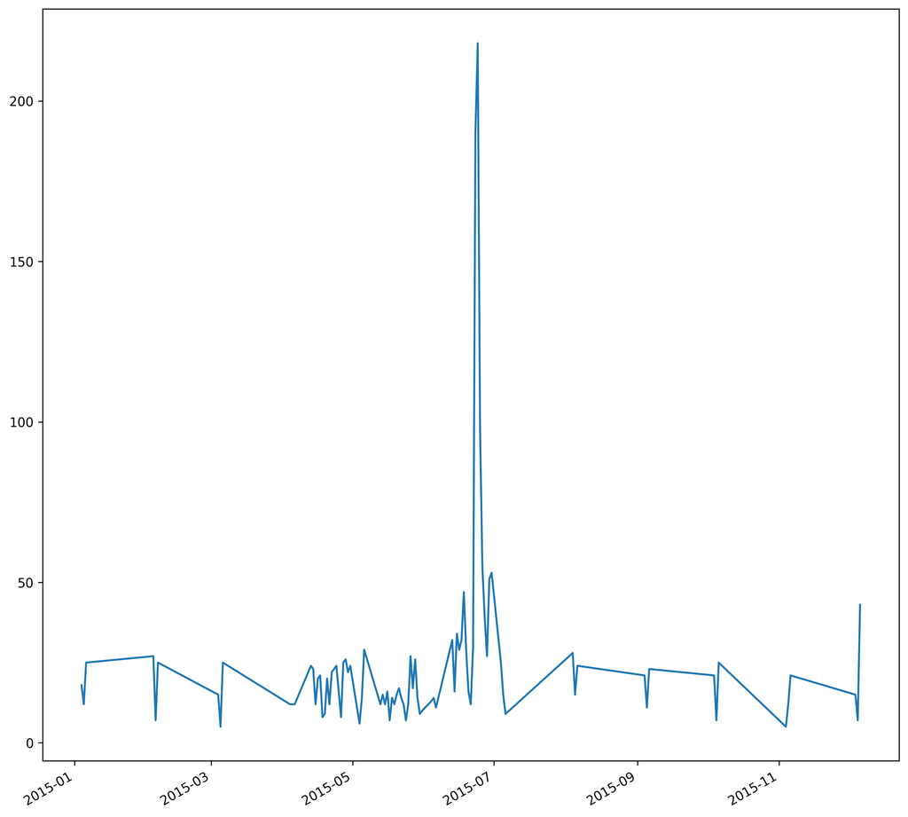

```python
a['Date_month_year_dt'].value_counts().index#.plot();
a['Date_month_year_dt'].value_counts().sort_index()
# make up some data
x = a['Date_month_year_dt'].value_counts().sort_index().index
y =a['Date_month_year_dt'].value_counts().sort_index()
plt.figure(num=None, figsize=(12, 12), dpi=300, facecolor='w', edgecolor='k')

# plot
plt.plot(x,y)
# beautify the x-labels
plt.gcf().autofmt_xdate()
plt.show()
#a['Date_month_year_dt'].value_counts().plot();
```

More commplaints happened between montth 6 and 7 (june and july) Now plot monthly data

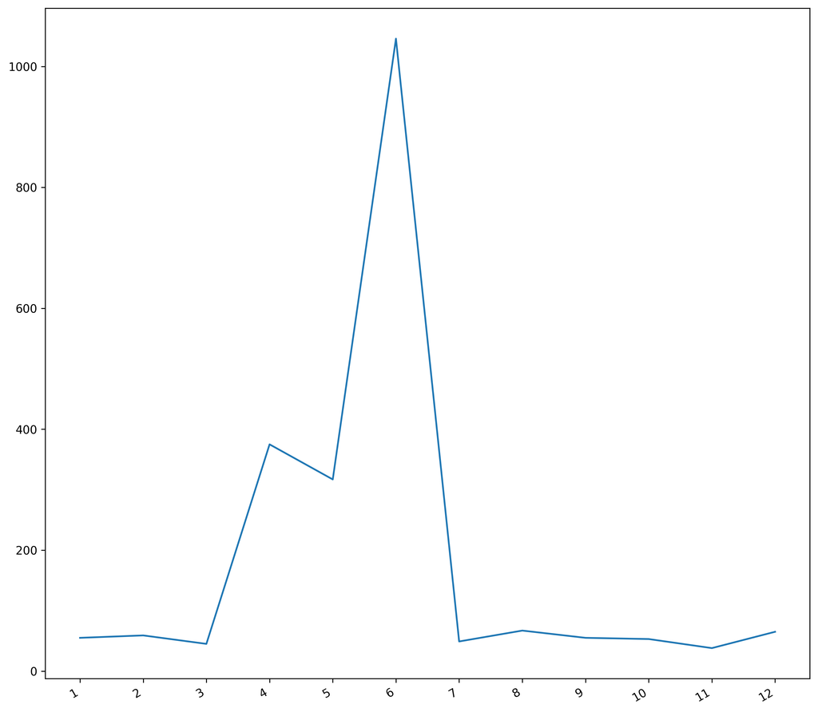

```python
a.sort_values('month')
a['month'].value_counts().sort_index()
# make up some data
x = a['month'].value_counts().sort_index().index
y =a['month'].value_counts().sort_index()
# plot

plt.figure(num=None, figsize=(12, 12), dpi=300, facecolor='w', edgecolor='k')
plt.plot(x,y)

# beautify the x-labels
plt.gcf().autofmt_xdate()
plt.xticks(x)
plt.show()
#we have major spike in complaints on June month
```

```python
a["day"]=a.apply(lambda row: row.Datetime.day,axis=1)#(row.ClosedDate.year))
a['day']
```

```
Date_month_year_dt
2015-01-04    4
2015-01-04    4
2015-01-04    4
2015-01-04    4
2015-01-04    4
             ..
2015-12-06    6
2015-12-06    6
2015-12-06    6
2015-12-06    6
2015-12-06    6
Name: day, Length: 2224, dtype: int64
```

- Provide the trend chart for the number of complaints at monthly and daily granularity levels.

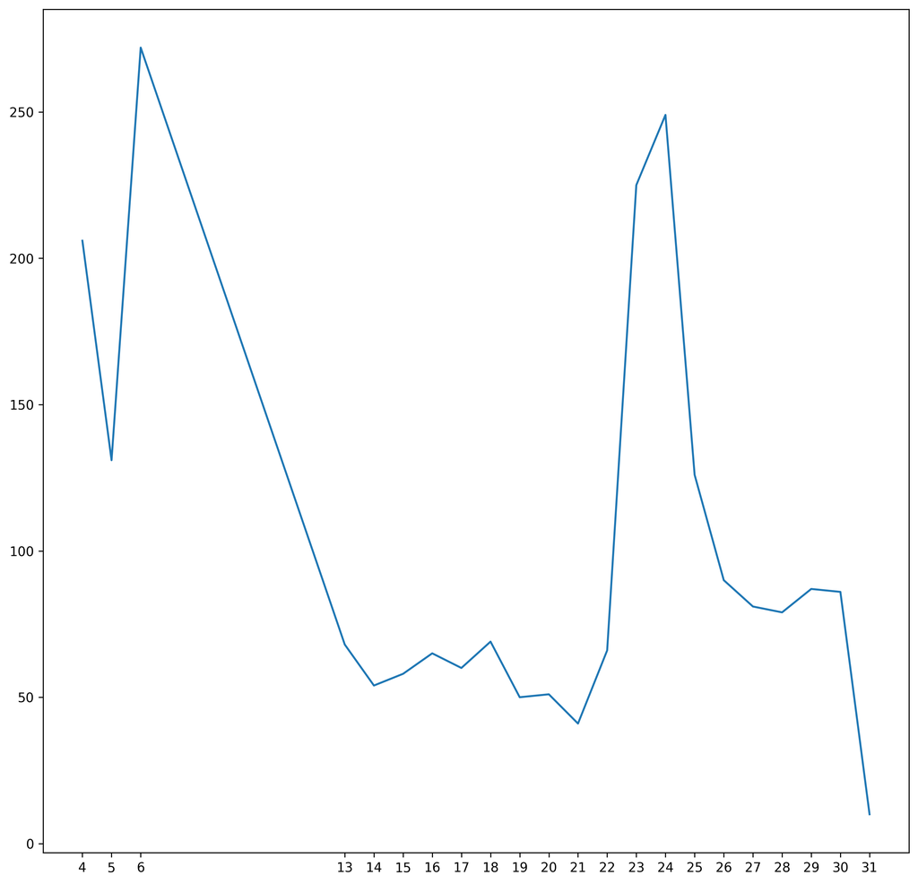

```python
a.sort_values('day')
a['day'].value_counts().sort_index()
# make up some data
x = a['day'].value_counts().sort_index().index
y =a['day'].value_counts().sort_index()

plt.figure(num=None, figsize=(12, 12), dpi=300, facecolor='w', edgecolor='k')
# plot
plt.plot(x,y)

# beautify the x-labels
#plt.gcf().autofmt_xdate()
plt.xticks(x)
plt.show()
```

first week and last 10 days of month seem to have more complaints

```python
a.columns
#we do not have complaint type in our data
```

```
Index(['Ticket #', 'Customer Complaint', 'Date', 'Date_month_year', 'Time',
       'Received Via', 'City', 'State', 'Zip code', 'Status',
       'Filing on Behalf of Someone', 'Datetime', 'Date_month_year_dt',
       'month', 'day'],
      dtype='object')
```

```python
a.columns=a.columns.str.replace(' ','')
#remove spaces from columns for ease
a.columns
classes=pd.read_excel("Classifier.xlsx") #import datasetb=pd.read_csv("Comcast_telecom_complaints_data.csv") #import dataset
```

We manually labeled some of the data with complaint type this will be used to train and test our model to commpute complaint type

We will see that this is inaccuurate(max around 70% accuracy) and later at end we will try NLP Using LDA with unsuperwised learning which would also eleminate manual labelling effort taken in this method however lets see the output of supervised methods and check accuracy levels for this particular problem with different models and algorithms

```python
from sklearn.utils import shuffle
classes = shuffle(classes)
classes
classes.columns=classes.columns.str.replace(' ','')
classes.columns
```

```
Index(['CustomerComplaint', 'Type'], dtype='object')
```

```python
classes.head
#drop the complaint types that are rare/amb
classes['Type'].replace({'suupport':'support'},inplace=True)
#classes=classes[classes["Type"]!='suupport']
classes['Type'].replace({'health':'misc'},inplace=True)

classes['Type'].replace({'others':'misc'},inplace=True)
#classes=classes[classes["Type"]!='misc']

classes.Type.unique()
```

```
array(['payment and charges', 'Data usage limit', 'customer sentiment',
       'service termination/ not setup right', 'service not working',
       'misc', 'cable', 'support', 'Internet Speed',
       'Customer Care Feedback', 'Blockage', 'Unwanted service'],
      dtype=object)
```

```python
classes.Type.unique()
```

```
array(['payment and charges', 'Data usage limit', 'customer sentiment',
       'service termination/ not setup right', 'service not working',
       'misc', 'cable', 'support', 'Internet Speed',
       'Customer Care Feedback', 'Blockage', 'Unwanted service'],
      dtype=object)
```

```python
classes.Type.value_counts()
```

```
payment and charges                     113
Internet Speed                           53
Data usage limit                         50
customer sentiment                       33
misc                                     32
service not working                      30
support                                  25
service termination/ not setup right     19
Blockage                                 17
Customer Care Feedback                   13
Unwanted service                          9
cable                                     5
Name: Type, dtype: int64
```

```python
from io import StringIO
col = [ 'Type','CustomerComplaint' ]
df=classes
df = df[col]
df = df[pd.notnull(df['Type'])]

df['category_id'] = df['Type'].factorize()[0]

category_id_df = df[['Type', 'category_id']].drop_duplicates().sort_values('category_id')
category_to_id = dict(category_id_df.values)
id_to_category = dict(category_id_df[['category_id', 'Type']].values)
print(id_to_category)
df.head()
```

```
{0: 'payment and charges', 1: 'Data usage limit', 2: 'customer sentiment', 3: 'service termination/ not setup right', 4: 'service not working', 5: 'misc', 6: 'cable', 7: 'support', 8: 'Internet Speed', 9: 'Customer Care Feedback', 10: 'Blockage', 11: 'Unwanted service'}
```

|  | Type | CustomerComplaint | category_id |
| --- | --- | --- | --- |
| 179 | payment and charges | hidden fees, dropped internet connection | 0 |
| 32 | Data usage limit | Comcast using a Data Cap to take however much ... | 1 |
| 124 | customer sentiment | Comcast (Xfinity) Monopolistic Billing Practices | 2 |
| 125 | customer sentiment | Terrible waiting times | 2 |
| 233 | service termination/ not setup right | disconnection of service | 3 |

```python
from sklearn.feature_extraction.text import TfidfVectorizer
tfidf = TfidfVectorizer(sublinear_tf=True, min_df=5, norm='l2', encoding='latin-1', ngram_range=(1, 2), stop_words='english')
features = tfidf.fit_transform(df.CustomerComplaint).toarray()
labels = df.category_id
features.shape
```

```
(399, 53)
```

```python
from sklearn.feature_selection import chi2
import numpy as np
N = 2
#print(category_to_id.items())
for Type, category_id in sorted(category_to_id.items()):
  print(Type)
  features_chi2 = chi2(features, labels == category_id)
  indices = np.argsort(features_chi2[0])
  feature_names = np.array(tfidf.get_feature_names())[indices]
  unigrams = [v for v in feature_names if len(v.split(' ')) == 1]
  bigrams = [v for v in feature_names if len(v.split(' ')) == 2]
  print("# '{}':".format(Type))
  print("  . Most correlated unigrams:\n. {}".format('\n. '.join(unigrams[-N:])))
  print("  . Most correlated bigrams:\n. {}".format('\n. '.join(bigrams[-N:])))
```

```
Blockage
# 'Blockage':
  . Most correlated unigrams:
. contract
. hbo
  . Most correlated bigrams:
. comcast data
. comcast internet
Customer Care Feedback
# 'Customer Care Feedback':
  . Most correlated unigrams:
. poor
. customer
  . Most correlated bigrams:
. comcast service
. customer service
Data usage limit
# 'Data usage limit':
  . Most correlated unigrams:
. cap
. data
  . Most correlated bigrams:
. data cap
. comcast data
Internet Speed
# 'Internet Speed':
  . Most correlated unigrams:
. throttling
. speed
  . Most correlated bigrams:
. slow internet
. internet speed
Unwanted service
# 'Unwanted service':
  . Most correlated unigrams:
. services
. service
  . Most correlated bigrams:
. comcast data
. comcast internet
```

[output cut: 41 more lines]

```
# 'service termination/ not setup right':
  . Most correlated unigrams:
. service
. failure
  . Most correlated bigrams:
. comcast internet
. internet service
support
# 'support':
  . Most correlated unigrams:
. internet
. issues
  . Most correlated bigrams:
. service issues
. comcast internet
```

```python
from sklearn.model_selection import train_test_split
from sklearn.feature_extraction.text import CountVectorizer
from sklearn.feature_extraction.text import TfidfTransformer
from sklearn.naive_bayes import MultinomialNB
X_train, X_test, y_train, y_test = train_test_split(df['CustomerComplaint'], df['Type'], random_state = 0, test_size=0.2)
count_vect = CountVectorizer()
X_train_counts = count_vect.fit_transform(X_train)
tfidf_transformer = TfidfTransformer()
X_train_tfidf = tfidf_transformer.fit_transform(X_train_counts)
clf = MultinomialNB().fit(X_train_tfidf, y_train)
```

```python
print(clf.predict(count_vect.transform(["This company refuses to provide me verification and validation of debt per my right under the FDCPA. I do not believe this debt is mine."])))
```

```
['payment and charges']
```

```python
print(clf.predict(count_vect.transform(["This company is not giving proper info onn data cap limit"])))
```

```
['Data usage limit']
```

```python
print(clf.predict(count_vect.transform(["HBOgo ps4"])))
```

```
['payment and charges']
```

```python
print(clf.predict(count_vect.transform(["slow mbps"])))
```

```
['Internet Speed']
```

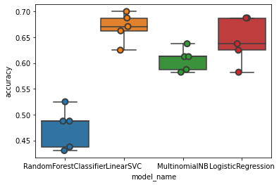

```python
from sklearn.linear_model import LogisticRegression
from sklearn.ensemble import RandomForestClassifier
from sklearn.svm import LinearSVC
from sklearn.model_selection import cross_val_score
models = [
    RandomForestClassifier(n_estimators=200, max_depth=3, random_state=0),
    LinearSVC(),
    MultinomialNB(),
    LogisticRegression(random_state=0),
]
CV = 5
cv_df = pd.DataFrame(index=range(CV * len(models)))
entries = []
for model in models:
  model_name = model.__class__.__name__
  accuracies = cross_val_score(model, features, labels, scoring='accuracy', cv=CV)
  for fold_idx, accuracy in enumerate(accuracies):
    entries.append((model_name, fold_idx, accuracy))
cv_df = pd.DataFrame(entries, columns=['model_name', 'fold_idx', 'accuracy'])
import seaborn as sns
sns.boxplot(x='model_name', y='accuracy', data=cv_df)
sns.stripplot(x='model_name', y='accuracy', data=cv_df,
              size=8, jitter=True, edgecolor="gray", linewidth=2)
plt.show()
```

Comparing different algorithms and models we find Linear SVC isperforming around 66-70% accurately but this is not enough for our particular use case and this consumed sufficient time for manual labelling

```python
cv_df.groupby('model_name').accuracy.mean()
```

```
model_name
LinearSVC                 0.669177
LogisticRegression        0.643956
MultinomialNB             0.606456
RandomForestClassifier    0.473576
Name: accuracy, dtype: float64
```

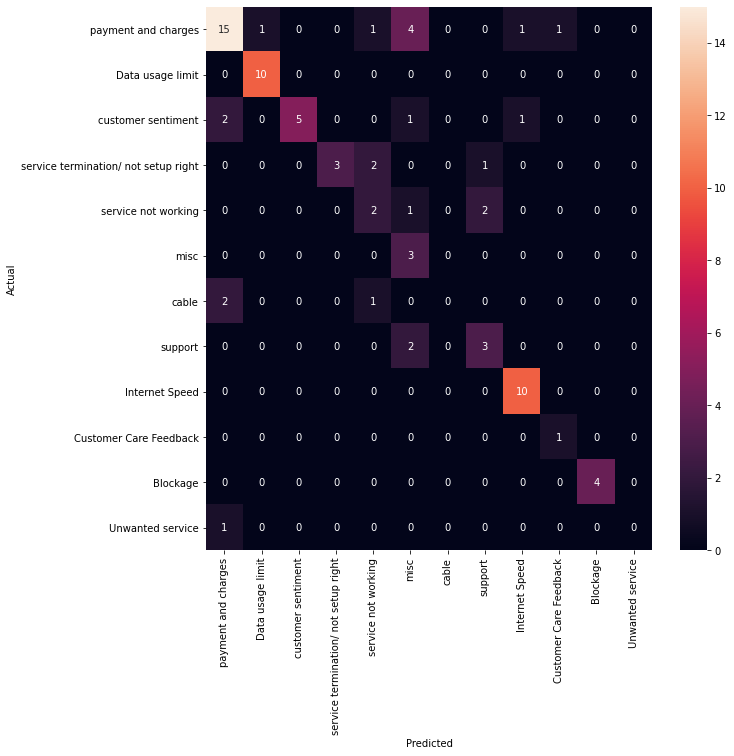

```python
model = LinearSVC()
X_train, X_test, y_train, y_test, indices_train, indices_test = train_test_split(features, labels, df.index, test_size=0.2, random_state=0)
model.fit(X_train, y_train)
y_pred = model.predict(X_test)
from sklearn.metrics import confusion_matrix
conf_mat = confusion_matrix(y_test, y_pred)
fig, ax = plt.subplots(figsize=(10,10))
sns.heatmap(conf_mat, annot=True, fmt='d',
            xticklabels=category_id_df.Type.values, yticklabels=category_id_df.Type.values)
plt.ylabel('Actual')
plt.xlabel('Predicted')
plt.show()
```

```python
#Cv
#from sklearn.cross_validation import train_test_split

#Classifier imports
from sklearn.neighbors import KNeighborsClassifier
from sklearn.naive_bayes import GaussianNB, MultinomialNB, BernoulliNB
from sklearn.linear_model import LogisticRegression, SGDClassifier
from sklearn.svm import SVC, LinearSVC, NuSVC

# Performance metrics
from sklearn.metrics import accuracy_score, classification_report


tfidf = TfidfVectorizer(sublinear_tf=True, min_df=5, norm='l2', encoding='latin-1', ngram_range=(1, 2), stop_words='english')
features = tfidf.fit_transform(df.CustomerComplaint).toarray()
labels = df.Type
features.shape

x1,x2,y1,y2, indices_train, indices_test = train_test_split(features, labels, df.index, test_size=0.25, random_state=0)
# Initialize our classifiers
gnb = GaussianNB()
KNN = KNeighborsClassifier(n_neighbors=1)
MNB = MultinomialNB()
BNB = BernoulliNB()
LR = LogisticRegression()
SDG = SGDClassifier()
SVC = SVC()
LSVC = LinearSVC()
NSVC = NuSVC()

# Train our classifier and test predict
gnb.fit(x1, y1)
y2_GNB_model = gnb.predict(x2)
print("GaussianNB Accuracy :", accuracy_score(y2, y2_GNB_model))

KNN.fit(x1,y1)
y2_KNN_model = KNN.predict(x2)
print("KNN Accuracy :", accuracy_score(y2, y2_KNN_model))

#MNB.fit(x1,y1)
#y2_MNB_model = MNB.predict(x2)
#print("MNB Accuracy :", accuracy_score(y2, y2_MNB_model))

BNB.fit(x1,y1)
y2_BNB_model = BNB.predict(x2)
print("BNB Accuracy :", accuracy_score(y2, y2_BNB_model))

LR.fit(x1,y1)
y2_LR_model = LR.predict(x2)
print("LR Accuracy :", accuracy_score(y2, y2_LR_model))

SDG.fit(x1,y1)
y2_SDG_model = SDG.predict(x2)
print("SDG Accuracy :", accuracy_score(y2, y2_SDG_model))

SVC.fit(x1,y1)
y2_SVC_model = SVC.predict(x2)
print("SVC Accuracy :", accuracy_score(y2, y2_SVC_model))

LSVC.fit(x1,y1)
y2_LSVC_model = LSVC.predict(x2)
print("LSVC Accuracy :", accuracy_score(y2, y2_LSVC_model))

#NSVC.fit(x1,y1)
#y2_NSVC_model = NSVC.predict(x2)
#print("NSVC Accuracy :", accuracy_score(y2, y2_NSVC_model))
```

```
GaussianNB Accuracy : 0.5
KNN Accuracy : 0.56
BNB Accuracy : 0.49
LR Accuracy : 0.62
SDG Accuracy : 0.65
SVC Accuracy : 0.63
LSVC Accuracy : 0.66
```

```python
model.fit(features, labels)
N = 2
for Product, category_id in sorted(category_to_id.items()):
  indices = np.argsort(model.coef_[category_id])
  feature_names = np.array(tfidf.get_feature_names())[indices]
  unigrams = [v for v in reversed(feature_names) if len(v.split(' ')) == 1][:N]
  bigrams = [v for v in reversed(feature_names) if len(v.split(' ')) == 2][:N]
  print("# '{}':".format(Product))
  print("  . Top unigrams:\n       . {}".format('\n       . '.join(unigrams)))
  print("  . Top bigrams:\n       . {}".format('\n       . '.join(bigrams)))
```

```
# 'Blockage':
  . Top unigrams:
       . failure
       . service
  . Top bigrams:
       . internet service
       . comcast xfinity
# 'Customer Care Feedback':
  . Top unigrams:
       . problem
       . poor
  . Top bigrams:
       . service issues
       . internet service
# 'Data usage limit':
  . Top unigrams:
       . customer
       . poor
  . Top bigrams:
       . customer service
       . service issues
# 'Internet Speed':
  . Top unigrams:
       . billing
       . pricing
  . Top bigrams:
       . comcast billing
       . internet speeds
# 'Unwanted service':
  . Top unigrams:
       . issues
       . internet
  . Top bigrams:
       . comcast internet
       . data usage
# 'cable':
  . Top unigrams:
       . complaint
       . practices
  . Top bigrams:
```

[output cut: 29 more lines]

```
       . data cap
# 'service termination/ not setup right':
  . Top unigrams:
       . speed
       . speeds
  . Top bigrams:
       . slow internet
       . comcast throttling
# 'support':
  . Top unigrams:
       . customer
       . xfinity
  . Top bigrams:
       . comcast service
       . comcast xfinity
```

```python
a.dtypes
```

```
Ticket#                            object
CustomerComplaint                  object
Date                               object
Date_month_year                    object
Time                               object
ReceivedVia                        object
City                               object
State                              object
Zipcode                             int64
Status                             object
FilingonBehalfofSomeone            object
Datetime                   datetime64[ns]
Date_month_year_dt         datetime64[ns]
month                               int64
day                                 int64
dtype: object
```

```python
a.columns

a['Type']=a.CustomerComplaint.apply(lambda row: str(LSVC.predict(tfidf.transform([row]))).lstrip('[\'').rstrip('\']'))
```

```python
print(model.predict(tfidf.transform(["slow mbps"])))
```

```
['Internet Speed']
```

```python
print(LSVC.predict(tfidf.transform(["hidden bill"])))
```

```
['payment and charges']
```

```python
print(a['Type'].unique())
```

```
['misc' 'payment and charges' 'service termination/ not setup right'
 'service not working' 'Internet Speed' 'Customer Care Feedback'
 'Data usage limit' 'support' 'customer sentiment' 'Blockage']
```

```python
frequencytype = pd.crosstab(index=a["Type"],columns="occur_count")
frequencytype

#Provide a table with the frequency of complaint types.
```

| col_0 Type | occur_count |
| --- | --- |
| Blockage | 41 |
| Customer Care Feedback | 84 |
| Data usage limit | 241 |
| Internet Speed | 258 |
| customer sentiment | 91 |
| misc | 442 |
| payment and charges | 659 |
| service not working | 139 |
| service termination/ not setup right | 63 |
| support | 206 |

```python
a.Type.unique()
```

```
array(['misc', 'payment and charges',
       'service termination/ not setup right', 'service not working',
       'Internet Speed', 'Customer Care Feedback', 'Data usage limit',
       'support', 'customer sentiment', 'Blockage'], dtype=object)
```

Which complaint types are maximum i.e., around internet, network issues, or across any other domains.

```
Maximum complaints are from payments and charges reg. billing, misc charges, etc
```

payment and charges

```
Followed by internet speed and data usage limit, support and service not working
```

Internet Speed

```
Data usage limit

suppoort

service not working
```

Create a new categorical variable with value as Open and Closed. Open & Pending is to be categorized as Open and Closed & Solved is to be categorized as Closed.

```python
a['CompState']=a.Status.apply(lambda temp: "Open" if temp in ["Open",'Pending'] else "Closed")
a.State = a.State.str.upper()
a.State.unique()
```

```
array(['ILLINOIS', 'PENNSYLVANIA', 'GEORGIA', 'ALABAMA', 'CALIFORNIA',
       'TENNESSEE', 'FLORIDA', 'COLORADO', 'WASHINGTON', 'DELAWARE',
       'NEW JERSEY', 'INDIANA', 'MISSISSIPPI', 'MICHIGAN', 'VIRGINIA',
       'RHODE ISLAND', 'OREGON', 'NEW MEXICO', 'SOUTH CAROLINA',
       'MARYLAND', 'DISTRICT OF COLUMBIA', 'TEXAS', 'UTAH',
       'MASSACHUSETTS', 'NEVADA', 'MINNESOTA', 'ARIZONA', 'LOUISIANA',
       'MISSOURI', 'NEW YORK', 'NEW HAMPSHIRE', 'WEST VIRGINIA', 'KANSAS',
       'KENTUCKY', 'OHIO', 'NORTH CAROLINA', 'CONNECTICUT', 'ARKANSAS',
       'VERMONT', 'MAINE', 'MONTANA', 'IOWA'], dtype=object)
```

```python
a['CompState'].unique()
#a[['CompState','Status']]
#- Create a new categorical variable with value as Open and Closed. Open & Pending is to be categorized as Open and Closed & Solved is to be categorized as Closed.
#a.columns
```

```
array(['Closed', 'Open'], dtype=object)
```

```python
a.head()
```

| Date_month_year_dt | Ticket# | CustomerComplaint | Date | Date_month_year | Time | ReceivedVia | City | State | Zipcode | Status | FilingonBehalfofSomeone | Datetime | Date_month_year_dt | month | day | Type | CompState |
| --- | --- | --- | --- | --- | --- | --- | --- | --- | --- | --- | --- | --- | --- | --- | --- | --- | --- |
| 2015-01-04 | 211255 | Comcast harassment | 04-01-15 | 04-Jan-15 | 12:18:47 AM | Customer Care Call | Schaumburg | ILLINOIS | 60193 | Closed | No | 2015-01-04 00:18:47 | 2015-01-04 | 1 | 4 | misc | Closed |
| 2015-01-04 | 211472 | comcast cable | 04-01-15 | 04-Jan-15 | 10:43:20 AM | Customer Care Call | Lockport | ILLINOIS | 60441 | Closed | No | 2015-01-04 10:43:20 | 2015-01-04 | 1 | 4 | payment and charges | Closed |
| 2015-01-04 | 211478 | Comcast | 04-01-15 | 04-Jan-15 | 10:47:35 AM | Internet | North Huntingdon | PENNSYLVANIA | 15642 | Closed | No | 2015-01-04 10:47:35 | 2015-01-04 | 1 | 4 | misc | Closed |
| 2015-01-04 | 211677 | Comcast refusal of service | 04-01-15 | 04-Jan-15 | 12:01:06 PM | Customer Care Call | Wayne | PENNSYLVANIA | 19087 | Closed | No | 2015-01-04 12:01:06 | 2015-01-04 | 1 | 4 | service termination/ not setup right | Closed |
| 2015-01-04 | 211775 | Horrible Service | 04-01-15 | 04-Jan-15 | 12:28:58 PM | Customer Care Call | Mckeesport | PENNSYLVANIA | 15132 | Closed | No | 2015-01-04 12:28:58 | 2015-01-04 | 1 | 4 | service not working | Closed |

```python
a[a["CompState"]!="Closed"].head()
```

| Date_month_year_dt | Ticket# | CustomerComplaint | Date | Date_month_year | Time | ReceivedVia | City | State | Zipcode | Status | FilingonBehalfofSomeone | Datetime | Date_month_year_dt | month | day | Type | CompState |
| --- | --- | --- | --- | --- | --- | --- | --- | --- | --- | --- | --- | --- | --- | --- | --- | --- | --- |
| 2015-01-05 | 268362 | tInternet Service Provider Complaint | 05-01-15 | 05-Jan-15 | 11:51:11 AM | Customer Care Call | Renton | WASHINGTON | 98055 | Open | No | 2015-01-05 11:51:11 | 2015-01-05 | 1 | 5 | customer sentiment | Open |
| 2015-01-05 | 268773 | Poor service from Comcast Xfinity | 05-01-15 | 05-Jan-15 | 2:01:54 PM | Internet | Milford | DELAWARE | 19963 | Open | No | 2015-01-05 14:01:54 | 2015-01-05 | 1 | 5 | misc | Open |
| 2015-01-05 | 268789 | about comcast | 05-01-15 | 05-Jan-15 | 2:04:56 PM | Internet | Richmond Hill | GEORGIA | 31324 | Open | No | 2015-01-05 14:04:56 | 2015-01-05 | 1 | 5 | misc | Open |
| 2015-01-06 | 316257 | Comcast Data Usage Meter | 06-01-15 | 06-Jan-15 | 9:44:42 AM | Customer Care Call | Senatobia | MISSISSIPPI | 38668 | Open | No | 2015-01-06 09:44:42 | 2015-01-06 | 1 | 6 | Data usage limit | Open |
| 2015-01-06 | 317426 | internet availability for students | 06-01-15 | 06-Jan-15 | 4:59:16 PM | Internet | Lake Tapps | WASHINGTON | 98391 | Open | Yes | 2015-01-06 16:59:16 | 2015-01-06 | 1 | 6 | support | Open |

```python
#- Provide state wise status of complaints in a stacked bar chart. Use the categorized variable from Q3. Provide insights on:


df_plot = a.groupby(['CompState', 'State']).size().reset_index().pivot(columns='CompState', index='State', values=0)
```

Provide state wise status of complaints in a stacked bar chart. Use the categorized variable from Q3. Provide insights on:

```python
a.State.value_counts().to_frame()[:15]
```

|  | State |
| --- | --- |
| GEORGIA | 288 |
| FLORIDA | 240 |
| CALIFORNIA | 220 |
| ILLINOIS | 164 |
| TENNESSEE | 143 |
| PENNSYLVANIA | 130 |
| MICHIGAN | 115 |
| WASHINGTON | 98 |
| COLORADO | 80 |
| MARYLAND | 78 |
| NEW JERSEY | 75 |
| TEXAS | 71 |
| MASSACHUSETTS | 61 |
| VIRGINIA | 60 |
| INDIANA | 59 |

```python
df_plot.fillna(0.0,inplace=True)
df_plot.head
```

```
<bound method NDFrame.head of CompState             Closed  Open
State
ALABAMA                 17.0   9.0
ARIZONA                 14.0   6.0
ARKANSAS                 6.0   0.0
CALIFORNIA             159.0  61.0
COLORADO                58.0  22.0
CONNECTICUT              9.0   3.0
DELAWARE                 8.0   4.0
DISTRICT OF COLUMBIA    15.0   2.0
FLORIDA                201.0  39.0
GEORGIA                208.0  80.0
ILLINOIS               135.0  29.0
INDIANA                 50.0   9.0
IOWA                     1.0   0.0
KANSAS                   1.0   1.0
KENTUCKY                 4.0   3.0
LOUISIANA               12.0   1.0
MAINE                    3.0   2.0
MARYLAND                63.0  15.0
MASSACHUSETTS           50.0  11.0
MICHIGAN                92.0  23.0
MINNESOTA               29.0   4.0
MISSISSIPPI             23.0  16.0
MISSOURI                 3.0   1.0
MONTANA                  1.0   0.0
NEVADA                   1.0   0.0
NEW HAMPSHIRE            8.0   4.0
NEW JERSEY              56.0  19.0
NEW MEXICO              11.0   4.0
NEW YORK                 6.0   0.0
NORTH CAROLINA           3.0   0.0
OHIO                     3.0   0.0
OREGON                  36.0  13.0
PENNSYLVANIA           110.0  20.0
RHODE ISLAND             1.0   0.0
SOUTH CAROLINA          15.0   3.0
TENNESSEE               96.0  47.0
TEXAS                   49.0  22.0
UTAH                    16.0   6.0
VERMONT                  2.0   1.0
VIRGINIA                49.0  11.0
WASHINGTON              75.0  23.0
WEST VIRGINIA            8.0   3.0>
```

- Provide state wise status of complaints in a stacked bar chart. Use the categorized variable from Q3. Provide insights on:

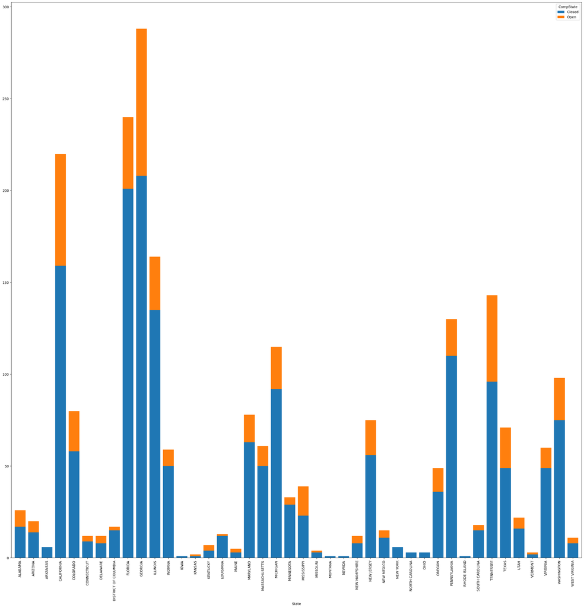

```python
import matplotlib.pyplot as plt
fig = plt.figure(dpi=140)
df_plot.plot(kind='bar', stacked=True,figsize=(30,30),ax = plt.gca(), width=0.8)
plt.rcParams.update({'font.size':30})
```

```python
df_plot['Total']=df_plot.Closed+df_plot.Open
```

```python
df_plot.head()
```

| CompState State | Closed | Open | Total |
| --- | --- | --- | --- |
| ALABAMA | 17.0 | 9.0 | 26.0 |
| ARIZONA | 14.0 | 6.0 | 20.0 |
| ARKANSAS | 6.0 | 0.0 | 6.0 |
| CALIFORNIA | 159.0 | 61.0 | 220.0 |
| COLORADO | 58.0 | 22.0 | 80.0 |

Which state has the maximum complaints GEORGIA Which state has the highest percentage of unresolved complaints KANSAS

```python
 #   Which state has the maximum complaints
print(df_plot[df_plot.Total==df_plot.Total.max()])
#Georgia
#  Which state has the highest percentage of unresolved complaints
df_plot['PercentUnresolved']=100* (df_plot.Open / df_plot.Total)

df_plot[df_plot.PercentUnresolved==df_plot.PercentUnresolved.max()]
#df_plot['PercentUnresolved']
```

```
CompState  Closed  Open  Total  PercentUnresolved
State
GEORGIA     208.0  80.0  288.0          27.777778
```

| CompState State | Closed | Open | Total | PercentUnresolved |
| --- | --- | --- | --- | --- |
| KANSAS | 1.0 | 1.0 | 2.0 | 50.0 |

but as kansas has only 2 complaints and kentucky has only 7 total complaints we don't have balance in amount of data avilable we can also look out for Mississippi amd maine for any data driven decisions to check why complaints stay open in certain states

```python
df_plot.sort_values(by=['PercentUnresolved','Total'],ascending=False)
```

| CompState State | Closed | Open | Total | PercentUnresolved |
| --- | --- | --- | --- | --- |
| KANSAS | 1.0 | 1.0 | 2.0 | 50.000000 |
| KENTUCKY | 4.0 | 3.0 | 7.0 | 42.857143 |
| MISSISSIPPI | 23.0 | 16.0 | 39.0 | 41.025641 |
| MAINE | 3.0 | 2.0 | 5.0 | 40.000000 |
| ALABAMA | 17.0 | 9.0 | 26.0 | 34.615385 |
| DELAWARE | 8.0 | 4.0 | 12.0 | 33.333333 |
| NEW HAMPSHIRE | 8.0 | 4.0 | 12.0 | 33.333333 |
| VERMONT | 2.0 | 1.0 | 3.0 | 33.333333 |
| TENNESSEE | 96.0 | 47.0 | 143.0 | 32.867133 |
| TEXAS | 49.0 | 22.0 | 71.0 | 30.985915 |
| ARIZONA | 14.0 | 6.0 | 20.0 | 30.000000 |
| GEORGIA | 208.0 | 80.0 | 288.0 | 27.777778 |
| CALIFORNIA | 159.0 | 61.0 | 220.0 | 27.727273 |
| COLORADO | 58.0 | 22.0 | 80.0 | 27.500000 |
| UTAH | 16.0 | 6.0 | 22.0 | 27.272727 |
| WEST VIRGINIA | 8.0 | 3.0 | 11.0 | 27.272727 |
| NEW MEXICO | 11.0 | 4.0 | 15.0 | 26.666667 |
| OREGON | 36.0 | 13.0 | 49.0 | 26.530612 |
| NEW JERSEY | 56.0 | 19.0 | 75.0 | 25.333333 |
| CONNECTICUT | 9.0 | 3.0 | 12.0 | 25.000000 |
| MISSOURI | 3.0 | 1.0 | 4.0 | 25.000000 |
| WASHINGTON | 75.0 | 23.0 | 98.0 | 23.469388 |
| MICHIGAN | 92.0 | 23.0 | 115.0 | 20.000000 |
| MARYLAND | 63.0 | 15.0 | 78.0 | 19.230769 |
| VIRGINIA | 49.0 | 11.0 | 60.0 | 18.333333 |
| MASSACHUSETTS | 50.0 | 11.0 | 61.0 | 18.032787 |
| ILLINOIS | 135.0 | 29.0 | 164.0 | 17.682927 |
| SOUTH CAROLINA | 15.0 | 3.0 | 18.0 | 16.666667 |
| FLORIDA | 201.0 | 39.0 | 240.0 | 16.250000 |
| PENNSYLVANIA | 110.0 | 20.0 | 130.0 | 15.384615 |
| INDIANA | 50.0 | 9.0 | 59.0 | 15.254237 |
| MINNESOTA | 29.0 | 4.0 | 33.0 | 12.121212 |
| DISTRICT OF COLUMBIA | 15.0 | 2.0 | 17.0 | 11.764706 |
| LOUISIANA | 12.0 | 1.0 | 13.0 | 7.692308 |
| ARKANSAS | 6.0 | 0.0 | 6.0 | 0.000000 |
| NEW YORK | 6.0 | 0.0 | 6.0 | 0.000000 |
| NORTH CAROLINA | 3.0 | 0.0 | 3.0 | 0.000000 |
| OHIO | 3.0 | 0.0 | 3.0 | 0.000000 |
| IOWA | 1.0 | 0.0 | 1.0 | 0.000000 |
| MONTANA | 1.0 | 0.0 | 1.0 | 0.000000 |
| NEVADA | 1.0 | 0.0 | 1.0 | 0.000000 |
| RHODE ISLAND | 1.0 | 0.0 | 1.0 | 0.000000 |

```python
a.columns
#df=a[a.
recvia_cnt=a.ReceivedVia.value_counts()
total=recvia_cnt[0]+recvia_cnt[1]
recvia_pct=100*(recvia_cnt/total)
recvia_pct
```

```
Customer Care Call    50.314748
Internet              49.685252
Name: ReceivedVia, dtype: float64
```

The percentage of complaints resolved till date, which were received through the Internet and customer care calls.

```python
int_sub=a[a.ReceivedVia=="Internet"]
cnt=int_sub.CompState.value_counts()
total=cnt[0]+cnt[1]

print(cnt)
print(total)
print(100*cnt[0]/total)
#76.28 % of complaints made from internet are resolved
```

```
Closed    843
Open      262
Name: CompState, dtype: int64
1105
76.289592760181
```

The percentage of complaints resolved till date, which were received through the Internet are 76.28 %

```python
int_sub=a[a.ReceivedVia=="Customer Care Call"]
cnt=int_sub.CompState.value_counts()
total=cnt[0]+cnt[1]

print(cnt)
print(total)
print(100*cnt[0]/total)

#77.211 % of complaints made from customer care call are resolved
```

```
Closed    864
Open      255
Name: CompState, dtype: int64
1119
77.21179624664879
```

The percentage of complaints resolved till date, which were received through customer care calls. are 77.21%

```python
#lets get bbetter with complaint type uusing nlp
from wordcloud import WordCloud, STOPWORDS
```

```python
data=a.CustomerComplaint.values
```

```python
wc=WordCloud(width=200,height=100,background_color='black',stopwords=STOPWORDS).generate(str(data))
```

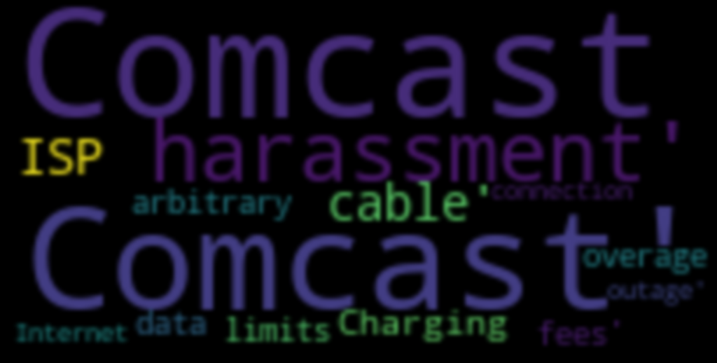

```python
fig=plt.figure(figsize=(20,29),facecolor='k',edgecolor='w')
plt.imshow(wc,interpolation='bicubic')
plt.axis("off")
plt.tight_layout()
plt.show()
```

we will use LDA TO GET ACCURATE CATEGORIZATION

```python
from nltk.corpus import stopwords
```

```python
from nltk.stem.wordnet import WordNetLemmatizer
```

```python
import string
```

```python
stop = set(stopwords.words('english'))
```

```python
exclude = set(string.punctuation)
```

```python
lemmma= WordNetLemmatizer() #base word conversion for bbetter tuning and performance
```

```python
def clean(doc):
    stop_free=" ".join([i for i in doc.lower().split() if i not in stop])
    punc_free="".join([char for char in stop_free if char not in exclude])
    normalisation = " ".join(lemmma.lemmatize(word) for word in punc_free.split(' '))
    return normalisation
```

```python
document=a['CustomerComplaint'].to_list()
```

```python
doc_clean=[clean(docu).split() for docu in document ]
```

```python
doc_clean[:10]
```

```
[['comcast', 'harassment'],
 ['comcast', 'cable'],
 ['comcast'],
 ['comcast', 'refusal', 'service'],
 ['horrible', 'service'],
 ['billing'],
 ['unable', 'get', 'touch', 'anyone', 'power', 'cancel', 'service'],
 ['fraudulent', 'claim', 'reported', 'collection', 'agency'],
 ['internet', 'service'],
 ['comcast', 'lied', 'pricing', 'installation']]
```

```python
import gensim
```

```python
from gensim import corpora
```

```python
dictionary=corpora.Dictionary(doc_clean)
```

```python
print(dictionary)
```

```
Dictionary(1412 unique tokens: ['comcast', 'harassment', 'cable', 'refusal', 'service']...)
```

```python
doc_word_freqcies=[dictionary.doc2bow(term) for term in doc_clean]
doc_word_freqcies[:30]
```

```
[[(0, 1), (1, 1)],
 [(0, 1), (2, 1)],
 [(0, 1)],
 [(0, 1), (3, 1), (4, 1)],
 [(4, 1), (5, 1)],
 [(6, 1)],
 [(4, 1), (7, 1), (8, 1), (9, 1), (10, 1), (11, 1), (12, 1)],
 [(13, 1), (14, 1), (15, 1), (16, 1), (17, 1)],
 [(4, 1), (18, 1)],
 [(0, 1), (19, 1), (20, 1), (21, 1)],
 [(0, 1),
  (22, 1),
  (23, 1),
  (24, 1),
  (25, 1),
  (26, 2),
  (27, 1),
  (28, 1),
  (29, 1),
  (30, 1)],
 [(0, 1), (2, 1)],
 [(31, 1)],
 [(0, 1), (4, 1), (32, 1), (33, 1), (34, 1)],
 [(6, 1), (35, 1)],
 [(36, 1), (37, 1)],
 [(4, 1), (38, 1)],
 [(0, 1), (39, 1), (40, 1), (41, 1), (42, 1), (43, 1), (44, 1)],
 [(18, 1),
  (45, 1),
  (46, 1),
  (47, 1),
  (48, 1),
  (49, 1),
  (50, 1),
  (51, 2),
  (52, 1),
  (53, 1),
  (54, 1),
  (55, 1)],
 [(0, 1), (48, 1), (56, 1)],
 [(48, 1), (51, 1)],
 [(4, 1), (57, 1), (58, 1), (59, 1)],
 [(0, 1)],
 [(0, 1), (4, 1), (60, 1), (61, 1)],
 [(0, 1)],
 [(6, 1), (16, 1)],
 [(4, 1), (12, 1), (62, 1), (63, 1), (64, 1), (65, 1)],
 [(0, 1), (66, 1), (67, 1), (68, 1), (69, 1), (70, 1)],
 [(35, 1), (62, 1)],
 [(16, 1), (71, 1), (72, 1), (73, 1), (74, 1)]]
```

```python
from gensim.models import LdaModel
```

```python
model=LdaModel(doc_word_freqcies,num_topics=5,id2word=dictionary,passes=1000)
```

```python
types= model.show_topics()
for t in types:
    print(t)
    print('----------------')
```

```
(0, '0.231*"comcast" + 0.107*"service" + 0.081*"internet" + 0.063*"billing" + 0.030*"customer" + 0.027*"issue" + 0.026*"complaint" + 0.018*"charge" + 0.015*"cable" + 0.012*"problem"')
----------------
(1, '0.035*"fee" + 0.034*"charged" + 0.033*"charging" + 0.030*"bill" + 0.023*"service" + 0.017*"modem" + 0.014*"month" + 0.013*"lower" + 0.013*"never" + 0.012*"rental"')
----------------
(2, '0.127*"comcast" + 0.122*"data" + 0.101*"cap" + 0.025*"slow" + 0.022*"comcastxfinity" + 0.019*"usage" + 0.018*"throttling" + 0.013*"email" + 0.011*"overage" + 0.009*"help"')
----------------
(3, '0.058*"service" + 0.055*"comcast" + 0.051*"practice" + 0.043*"billing" + 0.031*"unfair" + 0.017*"hbo" + 0.015*"deceptive" + 0.014*"issue" + 0.011*"call" + 0.011*"false"')
----------------
(4, '0.133*"internet" + 0.095*"speed" + 0.063*"comcast" + 0.035*"service" + 0.016*"xfinity" + 0.016*"connection" + 0.015*"pricing" + 0.014*"paying" + 0.013*"price" + 0.013*"high"')
----------------
```

```python
diction={}
for i in range(5):
    words=model.show_topic(i,topn=20)
    #print(words)
    diction["Topic number" + "{}".format(i)]=[i[0] for i in words]


pd.DataFrame(diction)
```

|  | Topic number0 | Topic number1 | Topic number2 | Topic number3 | Topic number4 |
| --- | --- | --- | --- | --- | --- |
| 0 | comcast | fee | comcast | service | internet |
| 1 | service | charged | data | comcast | speed |
| 2 | internet | charging | cap | practice | comcast |
| 3 | billing | bill | slow | billing | service |
| 4 | customer | service | comcastxfinity | unfair | xfinity |
| 5 | issue | modem | usage | hbo | connection |
| 6 | complaint | month | throttling | deceptive | pricing |
| 7 | charge | lower | email | issue | paying |
| 8 | cable | never | overage | call | price |
| 9 | problem | rental | help | false | high |
| 10 | poor | owned | charge | go | advertised |
| 11 | failure | cable | promised | switch | without |
| 12 | unauthorized | charge | limit | sale | issue |
| 13 | bad | provided | pay | lack | access |
| 14 | account | overcharged | cancellation | complaint | business |
| 15 | phone | back | credit | misleading | connectivity |
| 16 | horrible | lied | plan | bait | poor |
| 17 | tv | tv | failure | ps4 | day |
| 18 | fraud | technician | changed | xfinitycomcast | inconsistent |
| 19 | provide | failing | content | business | bill |

```python
import pyLDAvis.gensim
```

```python
Vis=pyLDAvis.gensim.prepare(model,doc_word_freqcies,dictionary,sort_topics=False)
```

```python
pyLDAvis.display(Vis)
#topic 2 and 4  is billing practice
#topic 3 is data cap issues
#topic 5 IS internet  speed
#topic 1 is internet and cable service

#
# billing practice and fairness has highest frequency
#topic data cap is 2nd most frequent
# topic internet speed is 3rd most frequent
```

[interactive chart not shown]